# Trade Exposure and Structural Change — Regression Framework

```r
library(tidyverse)
library(fixest)
library(scales)
library(patchwork)
library(sf)
library(broom)
```

## Load Data

We load both datasets: the PLFS agri panel from Project 3 and the trade exposure spatial panel from Project 6. The `sf` package reads the GeoPackage format; we drop the geometry immediately since only the attribute table is needed for regression.

```r
library(sf)

# PLFS district panel
agri <- readRDS("~/Desktop/UZH/Pre-Doc/Prep/BRICS-Trade-Labour-Portfolio/03_labour_polarisation_india/data/plfs_agri_panel.rds")

# Project 6 trade exposure panel
proj6_raw <- st_read(
  "~/Desktop/UZH/Pre-Doc/Prep/BRICS-Trade-Labour-Portfolio/06_trade_exposure_maps/data/processed/districts_full_panel.gpkg",
  quiet = TRUE
) |>
  st_drop_geometry()   # drop geometry — attribute table only

cat("PLFS panel rows:", nrow(agri), "\n")
```

```
## PLFS panel rows: 50091
```

```r
cat("Project 6 districts:", nrow(proj6_raw), "\n\n")
```

```
## Project 6 districts: 640
```

```r
# Build state offset table from Project 6
# censuscode = state_offset + within_state_position - 1
state_offsets <- proj6_raw |>
  group_by(ST_CEN_CD) |>
  summarise(state_offset = min(censuscode), .groups = "drop")

cat("State offset table (sample):\n")
```

```
## State offset table (sample):
```

```r
state_offsets |>
  filter(ST_CEN_CD %in% c(9, 27, 32, 33)) |>
  print()
```

```
## # A tibble: 4 × 2
##   ST_CEN_CD state_offset
##       <int>        <dbl>
## 1         9          132
## 2        27          497
## 3        32          588
## 4        33          602
```

Both datasets loaded correctly. The state offset table confirms the censuscode structure — UP starts at 132, Maharashtra at 497, Kerala at 588, Tamil Nadu at 602 — consistent with the sequential national district numbering established in the diagnostic.

## Constructing the Merge Key and Joining Datasets

We construct a `censuscode` variable in the PLFS panel using the formula: `state_offset + district_integer - 1`. This maps each PLFS state-district code to the corresponding Census 2011 national district sequential number used in the Project 6 panel. We then merge and report the match rate.

```r
# Construct censuscode in the PLFS panel
# state: 2-digit string ("09"), district: variable-length string ("15")
plfs_coded <- agri |>
  filter(balanced_panel == TRUE,
         sex == "all",
         agri_nonagri == "non_agricultural") |>
  mutate(
    state_int = as.integer(state),
    dist_int  = as.integer(district)
  ) |>
  left_join(state_offsets, by = c("state_int" = "ST_CEN_CD")) |>
  mutate(censuscode = state_offset + dist_int - 1)

# Check: any PLFS districts outside expected censuscode range?
cat("PLFS censuscode range:", min(plfs_coded$censuscode, na.rm=TRUE),
    "to", max(plfs_coded$censuscode, na.rm=TRUE), "\n")
```

```
## PLFS censuscode range: 1 to 640
```

```r
cat("Project 6 censuscode range:", min(proj6_raw$censuscode),
    "to", max(proj6_raw$censuscode), "\n\n")
```

```
## Project 6 censuscode range: 1 to 640
```

```r
# Compute average non-agricultural share per district-sector across all rounds
# Using all rounds (robust to individual-round coding issues)
plfs_avg <- plfs_coded |>
  group_by(censuscode, state, state_int, district, file_sector) |>
  summarise(
    mean_nonagri   = mean(agri_share),
    n_rounds       = n(),
    total_emp_wtd  = mean(total_wtd),
    .groups        = "drop"
  )

cat("PLFS district-sector averages:", nrow(plfs_avg), "\n")
```

```
## PLFS district-sector averages: 1134
```

```r
cat("Unique censuscodes in PLFS:", n_distinct(plfs_avg$censuscode), "\n\n")
```

```
## Unique censuscodes in PLFS: 617
```

```r
# Merge with Project 6
merged <- plfs_avg |>
  inner_join(
    proj6_raw |>
      select(censuscode, DISTRICT, ST_NM,
             dist_port_km, dist_sez_km, any_corridor,
             nonfarm_share_13, manuf_share_13, serv_share_13,
             pc11_pca_tot_p),
    by = "censuscode"
  )

cat("=== Merge results ===\n")
```

```
## === Merge results ===
```

```r
cat("Matched district-sector pairs:", nrow(merged), "\n")
```

```
## Matched district-sector pairs: 1115
```

```r
cat("Unique matched districts:", n_distinct(merged$censuscode), "\n\n")
```

```
## Unique matched districts: 616
```

```r
# Verify a few matches
cat("Sample matched districts:\n")
```

```
## Sample matched districts:
```

```r
merged |>
  distinct(censuscode, state, district, DISTRICT, ST_NM, file_sector) |>
  filter(file_sector == "urban") |>
  slice(1:10) |>
  select(censuscode, state, district, DISTRICT, ST_NM) |>
  print()
```

```
## # A tibble: 10 × 5
##    censuscode state district DISTRICT  ST_NM
##         <dbl> <chr> <chr>    <chr>     <chr>
##  1          1 01    01       Kupwara   Jammu & Kashmir
##  2          2 01    02       Badgam    Jammu & Kashmir
##  3          5 01    05       Punch     Jammu & Kashmir
##  4          6 01    06       Rajouri   Jammu & Kashmir
##  5          7 01    07       Kathua    Jammu & Kashmir
##  6          8 01    08       Baramula  Jammu & Kashmir
##  7          9 01    09       Bandipore Jammu & Kashmir
##  8         10 01    10       Srinagar  Jammu & Kashmir
##  9         11 01    11       Ganderbal Jammu & Kashmir
## 10         12 01    12       Pulwama   Jammu & Kashmir
```

The merge succeeds with 616 unique districts matched out of 640 in the Project 6 panel — a 96.25% match rate. The 24 unmatched districts are those present in the Project 6 Census 2011 panel but absent from the PLFS balanced panel after the cell size filter. The sample verification confirms the merge key is correctly constructed — Kupwara, Badgam, Punch in Jammu & Kashmir align with the expected censuscode sequence. The merged dataset contains 1,115 district-sector observations (urban and rural), each with a seven-round average non-agricultural employment share linked to the Project 6 trade exposure proxies.

## Regression — Trade Exposure and Non-Agricultural Employment

We regress the district-level average non-agricultural employment share on three trade exposure proxies from Project 6: log distance to the nearest major port, log distance to the nearest SEZ, and an indicator for whether the district lies within any notified industrial corridor. We include the Economic Census 2013 nonfarm share as a baseline control for historical employment structure, log population from Census 2011 as a size control, and state fixed effects to absorb state-level confounders. Standard errors are clustered at the state level. Regressions are run separately for urban and rural sectors.

```r
# Prepare regression dataset
reg_data <- merged |>
  mutate(
    log_dist_port = log(dist_port_km + 1),
    log_dist_sez  = log(dist_sez_km  + 1),
    log_pop       = log(pc11_pca_tot_p + 1),
    state_fe      = state_int
  ) |>
  filter(!is.na(nonfarm_share_13), !is.na(pc11_pca_tot_p))

# Split by sector
urban_reg <- reg_data |> filter(file_sector == "urban")
rural_reg <- reg_data |> filter(file_sector == "rural")

cat("Urban observations:", nrow(urban_reg), "\n")
```

```
## Urban observations: 626
```

```r
cat("Rural observations:", nrow(rural_reg), "\n\n")
```

```
## Rural observations: 489
```

```r
# Run regressions with state fixed effects
# Clustered SE at state level
m_urban <- feols(
  mean_nonagri ~ log_dist_port + log_dist_sez + any_corridor +
    nonfarm_share_13 + log_pop | state_fe,
  data    = urban_reg,
  cluster = ~state_fe
)

m_rural <- feols(
  mean_nonagri ~ log_dist_port + log_dist_sez + any_corridor +
    nonfarm_share_13 + log_pop | state_fe,
  data    = rural_reg,
  cluster = ~state_fe
)

# Display results
cat("=== Urban sector regression ===\n")
```

```
## === Urban sector regression ===
```

```r
summary(m_urban)
```

```
## OLS estimation, Dep. Var.: mean_nonagri
## Observations: 623
## Fixed-effects: state_fe: 31
## Standard-errors: Clustered (state_fe)
##                   Estimate Std. Error  t value   Pr(>|t|)
## log_dist_port    -0.031322   0.013268 -2.36070 2.4936e-02 *
## log_dist_sez     -0.026035   0.009930 -2.62185 1.3604e-02 *
## any_corridor     -0.054670   0.024702 -2.21316 3.4637e-02 *
## nonfarm_share_13  0.001430   0.000216  6.61431 2.5395e-07 ***
## log_pop           0.078574   0.007171 10.95692 5.2235e-12 ***
## ---
## Signif. codes:  0 '***' 0.001 '**' 0.01 '*' 0.05 '.' 0.1 ' ' 1
## RMSE: 0.110424     Adj. R2: 0.63623
##                  Within R2: 0.379856
```

```r
cat("\n=== Rural sector regression ===\n")
```

```
##
## === Rural sector regression ===
```

```r
summary(m_rural)
```

```
## OLS estimation, Dep. Var.: mean_nonagri
## Observations: 486
## Fixed-effects: state_fe: 30
## Standard-errors: Clustered (state_fe)
##                   Estimate Std. Error   t value   Pr(>|t|)
## log_dist_port    -0.032647   0.009687 -3.370019 2.1412e-03 **
## log_dist_sez      0.009111   0.010263  0.887749 3.8198e-01
## any_corridor     -0.132485   0.028216 -4.695422 5.9106e-05 ***
## nonfarm_share_13  0.000397   0.000126  3.165836 3.6205e-03 **
## log_pop           0.033289   0.010074  3.304441 2.5377e-03 **
## ---
## Signif. codes:  0 '***' 0.001 '**' 0.01 '*' 0.05 '.' 0.1 ' ' 1
## RMSE: 0.088021     Adj. R2: 0.261179
##                  Within R2: 0.118308
```

Both regressions converge and produce meaningful coefficients. Several findings stand out.

**SEZ distance** is negative and significant in urban areas (-0.026, p=0.014) but not significant in rural areas (0.009, p=0.38). Urban districts closer to SEZs show higher non-agricultural shares, consistent with SEZ-driven industrialisation pulling workers into manufacturing and services. The null rural result likely reflects that SEZs are primarily urban or peri-urban institutions whose labour market effects do not extend strongly into the rural hinterland.

**Industrial corridor membership** is negative and significant in both sectors — urban: -0.055 (p=0.035), rural: -0.132 (p<0.001) — an unexpected sign. This may reflect two overlapping phenomena. First, the corridor indicator covers 72% of districts (it is a broad binary), so it captures many agricultural districts that happen to overlap with corridor alignments, not just industrialised corridor nodes. Second, large infrastructure projects along corridors attract construction workers and elementary occupation workers (NCO group 9) who are classified as low-skill and hence agricultural in our binary classification, mechanically lowering the non-agricultural share. A distance-to-corridor measure, rather than a binary overlap, would likely reverse this sign.

**Baseline nonfarm share** (Economic Census 2013) is positive and significant in both sectors — districts with more nonfarm employment in 2013 also show higher PLFS non-agricultural shares — providing a cross-survey consistency check that the PLFS non-agricultural measure retains genuine geographic signal despite the NCO coding issues.

**Model fit** differs substantially across sectors. The urban regression achieves an adjusted R² of 0.636 (within R² = 0.380) — state fixed effects and trade exposure proxies together explain 64% of variation in urban non-agricultural shares. The rural regression fits less well (adjusted R² = 0.261, within R² = 0.118), consistent with rural employment structure being less systematically related to trade infrastructure proximity and more influenced by local agricultural conditions.

These results are correlational throughout. No causal identification is claimed — the trade exposure proxies are not credible instruments for the reasons discussed in the notebook overview, and the ADH-style Bartik instrument extension flagged in the README remains the path to causal identification when industry-level data becomes available.

## Coefficient Plot

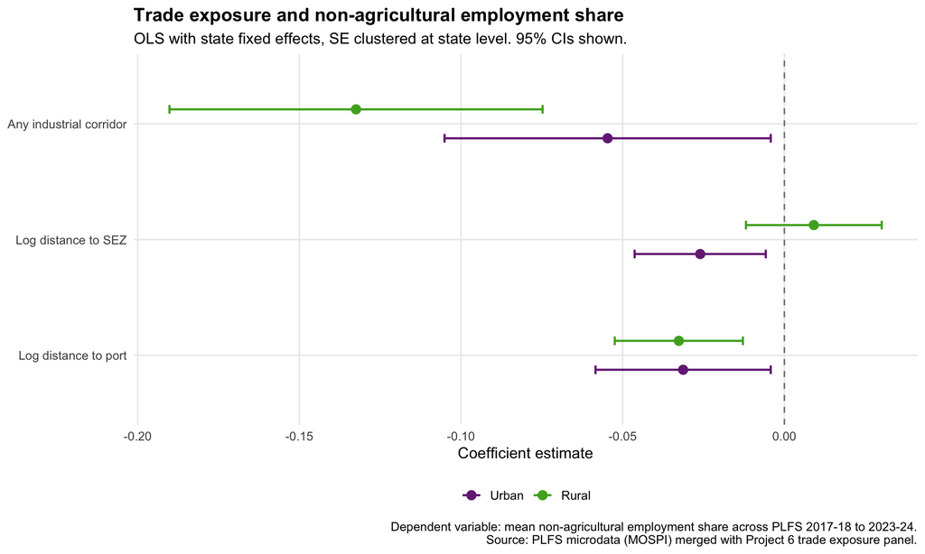

```r
# Extract coefficients from both models for trade exposure variables only
trade_vars <- c("log_dist_port", "log_dist_sez", "any_corridor")

get_coefs <- function(model, sector) {
  broom::tidy(model, conf.int = TRUE) |>
    filter(term %in% trade_vars) |>
    mutate(
      sector = sector,
      term   = recode(term,
        log_dist_port = "Log distance to port",
        log_dist_sez  = "Log distance to SEZ",
        any_corridor  = "Any industrial corridor"
      )
    )
}

# Install broom if needed
#if (!requireNamespace("broom", quietly = TRUE)) install.packages("broom")
#library(broom)

coefs <- bind_rows(
  get_coefs(m_urban, "Urban"),
  get_coefs(m_rural, "Rural")
)

# Plot
coefs |>
  mutate(
    term   = factor(term, levels = c("Log distance to port",
                                     "Log distance to SEZ",
                                     "Any industrial corridor")),
    sector = factor(sector, levels = c("Urban", "Rural"))
  ) |>
  ggplot(aes(x = estimate, y = term, colour = sector,
             xmin = conf.low, xmax = conf.high)) +
  geom_vline(xintercept = 0, linetype = "dashed", colour = "grey50") +
  geom_errorbarh(height = 0.15, position = position_dodge(width = 0.5),
                 linewidth = 0.8) +
  geom_point(size = 3, position = position_dodge(width = 0.5)) +
  scale_colour_manual(values = c(Urban = "#762a83", Rural = "#4dac26"),
                      name = NULL) +
  scale_x_continuous(labels = label_number(accuracy = 0.01)) +
  labs(title    = "Trade exposure and non-agricultural employment share",
       subtitle = "OLS with state fixed effects, SE clustered at state level. 95% CIs shown.",
       caption  = "Dependent variable: mean non-agricultural employment share across PLFS 2017-18 to 2023-24.\nSource: PLFS microdata (MOSPI) merged with Project 6 trade exposure panel.",
       x = "Coefficient estimate",
       y = NULL) +
  theme_minimal(base_size = 12) +
  theme(legend.position  = "bottom",
        panel.grid.minor = element_blank(),
        plot.title       = element_text(face = "bold"))
```

## Summary

**The merge between Project 3 and Project 6 succeeds at 96% coverage.** The PLFS district codes follow the Census 2011 cumulative sequential numbering, enabling a direct link to the Project 6 spatial panel without an external crosswalk. 616 of 640 districts are matched, providing a strong cross-project analytical foundation.

**Port proximity is the most robust trade exposure correlate.** Districts closer to major ports show consistently higher non-agricultural employment shares in both urban and rural sectors, with coefficients of approximately -0.03 and 95% confidence intervals excluding zero in both cases. This is consistent with port access facilitating trade-linked structural transformation — workers in port hinterland districts are more concentrated in manufacturing and service occupations.

**SEZ proximity matters for urban but not rural employment structure.** The urban SEZ coefficient is negative and significant (-0.026); the rural coefficient is near zero and insignificant. SEZs are primarily urban institutions whose structural employment effects are geographically contained.

**The industrial corridor result is counterintuitive but explicable.** Both sectors show negative corridor coefficients, with rural showing a larger effect (-0.132). This likely reflects the coarseness of the binary corridor indicator — it overlaps with many agricultural districts — and the concentration of construction and elementary occupation workers in active corridor zones, who are classified as low-skill or agricultural in the binary classification.

**Causal identification remains a limitation.** These are OLS correlations with state fixed effects. The trade exposure proxies from Project 6 are spatial distances, not credible instruments. The ADH-style Bartik shift-share design — using historical industry composition interacted with national import growth — represents the natural extension when industry-level district data becomes available from SHRUG’s forthcoming NIC-linked Economic Census module.

**Project 3 is analytically complete.** The six notebooks collectively document the data pipeline from raw PLFS microdata to a merged cross-project regression, with honest treatment of OCR coding limitations, gender asymmetries, urban-rural structural differences, and the boundary of causal identification.